# KEENANEARLY-ERIN-HOMEWORK-04

Erin Keenan Early

April 12, 2019

When we initially discussed the central limit theorem and confidence intervals, we showed how we could use bootstrapping to estimate standard errors and confidence intervals around certain parameter values, like the mean. Using bootstrapping, we could also do the same for estimating standard errors and CIs around regression parameters, such as β coefficients.

[1] Using the “KamilarAndCooperData.csv” dataset…

```r
library(readr)
f <- "https://raw.githubusercontent.com/difiore/ADA-2019/master/KamilarAndCooperData.csv"
d <- read_csv(f, col_names = TRUE)
names(d)
```

```
##  [1] "Scientific_Name"         "Family"
##  [3] "Genus"                   "Species"
##  [5] "Brain_Size_Species_Mean" "Brain_Size_Female_Mean"
##  [7] "Brain_size_Ref"          "Body_mass_male_mean"
##  [9] "Body_mass_female_mean"   "Mass_Dimorphism"
## [11] "Mass_Ref"                "MeanGroupSize"
## [13] "AdultMales"              "AdultFemale"
## [15] "AdultSexRatio"           "Social_Organization_Ref"
## [17] "InterbirthInterval_d"    "Gestation"
## [19] "WeaningAge_d"            "MaxLongevity_m"
## [21] "LitterSz"                "Life_History_Ref"
## [23] "GR_MidRangeLat_dd"       "Precip_Mean_mm"
## [25] "Temp_Mean_degC"          "AET_Mean_mm"
## [27] "PET_Mean_mm"             "Climate_Ref"
## [29] "HomeRange_km2"           "HomeRangeRef"
## [31] "DayLength_km"            "DayLengthRef"
## [33] "Territoriality"          "Fruit"
## [35] "Leaves"                  "Fauna"
## [37] "DietRef1"                "Canine_Dimorphism"
## [39] "Canine_Dimorphism_Ref"   "Feed"
## [41] "Move"                    "Rest"
## [43] "Social"                  "Activity_Budget_Ref"
```

…run a linear regression looking at log(HomeRange_km2) in relation to log(Body_mass_female_mean) and report your β coeffiecients (slope and intercept).

```r
homebody<- lm(log(HomeRange_km2)~log(Body_mass_female_mean), data=d)
summary(homebody)
```

```
##
## Call:
## lm(formula = log(HomeRange_km2) ~ log(Body_mass_female_mean),
##     data = d)
##
## Residuals:
##     Min      1Q  Median      3Q     Max
## -3.3929 -0.9433 -0.0126  1.0944  3.6826
##
## Coefficients:
##                            Estimate Std. Error t value Pr(>|t|)
## (Intercept)                -9.44123    0.67293  -14.03   <2e-16 ***
## log(Body_mass_female_mean)  1.03643    0.08488   12.21   <2e-16 ***
## ---
## Signif. codes:  0 '***' 0.001 '**' 0.01 '*' 0.05 '.' 0.1 ' ' 1
##
## Residual standard error: 1.423 on 135 degrees of freedom
##   (76 observations deleted due to missingness)
## Multiple R-squared:  0.5248, Adjusted R-squared:  0.5213
## F-statistic: 149.1 on 1 and 135 DF,  p-value: < 2.2e-16
```

The intercept is -9.44123 and the slope is 1.03643.

[2] Then, use bootstrapping to sample from your data 1000 times with replacement, each time fitting the same model and calculating the appropriate coefficients. [The size of each sample should be equivalent to the number of observations in your dataset.] This generates a sampling distribution for each β coefficient. Plot a histogram of these sampling distributions.

```r
n<- 44
home<- NULL
body<- NULL
model<- vector("list",1000)
beta0<- NULL
beta1<- NULL
for (i in 1:1000) {
  home <- sample(d$HomeRange_km2, size= 44, replace = TRUE, prob=NULL)
  body <- sample(d$Body_mass_female_mean, size= 44, replace = TRUE, prob=NULL)
  beta0[i]<- lm(home~body)$coefficients["(Intercept)"]
  beta1[i]<- lm(home~body)$coefficients["body"]
}

head(beta0)
```

```
## [1] 0.6514706 0.6216109 0.7859447 1.0687343 3.5565888 1.3111059
```

```r
head(beta1)
```

```
## [1]  1.752095e-05 -1.042693e-05  3.754799e-05  2.447382e-04 -1.218162e-05
## [6] -4.792475e-07
```

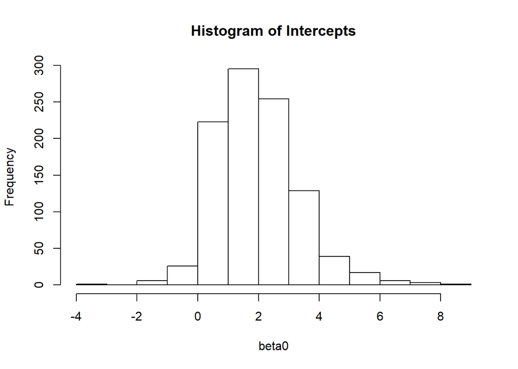

```r
hist(beta0, main="Histogram of Intercepts")
```

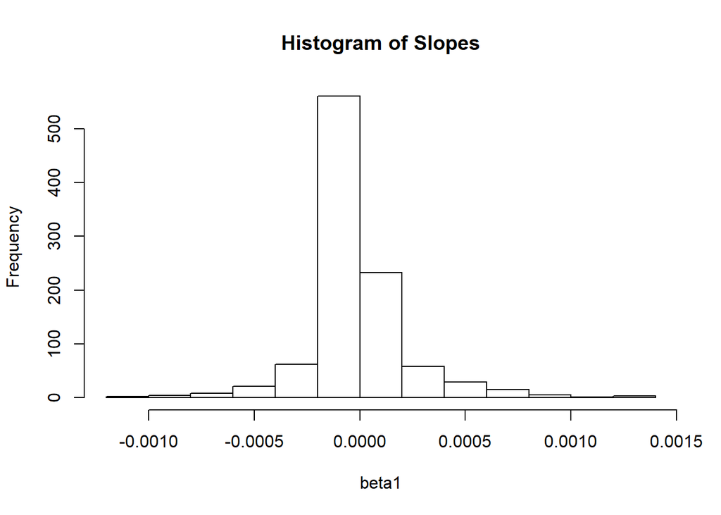

```r
hist(beta1, main="Histogram of Slopes")
```

[3] Estimate the standard error for each of your β coefficients as the standard deviation of the sampling distribution from your bootstrap.

```r
sem0<- sd(beta0)/sqrt(1000)
sem1<- sd(beta1)/sqrt(1000)
sem0
```

```
## [1] 0.04245658
```

```r
sem1
```

```
## [1] 7.226539e-06
```

[4] Also determine the 95% CI for each of your β coefficients based on the appropriate quantiles from your sampling distribution.

```r
ci0lower<- sem0*qnorm(0.025, mean=0, sd=1)
ci0upper<- sem0*qnorm(0.975, mean=0, sd=1)
ci1lower<- sem1*qnorm(0.025, mean=0, sd=1)
ci1upper<- sem1*qnorm(0.975, mean=0, sd=1)
ci0upper
```

```
## [1] 0.08321336
```

```r
ci0lower
```

```
## [1] -0.08321336
```

```r
ci1upper
```

```
## [1] 1.416376e-05
```

```r
ci1lower
```

```
## [1] -1.416376e-05
```

[5] How does your answer to part [3] compare to the SE estimated from your entire dataset using the formula for standard error implemented in lm()?

```r
summary(homebody)
```

```
##
## Call:
## lm(formula = log(HomeRange_km2) ~ log(Body_mass_female_mean),
##     data = d)
##
## Residuals:
##     Min      1Q  Median      3Q     Max
## -3.3929 -0.9433 -0.0126  1.0944  3.6826
##
## Coefficients:
##                            Estimate Std. Error t value Pr(>|t|)
## (Intercept)                -9.44123    0.67293  -14.03   <2e-16 ***
## log(Body_mass_female_mean)  1.03643    0.08488   12.21   <2e-16 ***
## ---
## Signif. codes:  0 '***' 0.001 '**' 0.01 '*' 0.05 '.' 0.1 ' ' 1
##
## Residual standard error: 1.423 on 135 degrees of freedom
##   (76 observations deleted due to missingness)
## Multiple R-squared:  0.5248, Adjusted R-squared:  0.5213
## F-statistic: 149.1 on 1 and 135 DF,  p-value: < 2.2e-16
```

```r
sem0
```

```
## [1] 0.04245658
```

```r
sem1
```

```
## [1] 7.226539e-06
```

My standard error for my lm() is 0.67293 for the intercept at 0.08488 for the slope.

[6] How does your answer to part [4] compare to the 95% CI estimated from your entire dataset?

```r
ciintlower<- 0.67293/qnorm(0.025, mean=0, sd=1)
ciintupper<- 0.67293/qnorm(0.975, mean=0, sd=1)
cisllower<- 0.08488/qnorm(0.025, mean=0, sd=1)
cislupper<- 0.08488/qnorm(0.975, mean=0, sd=1)
ciintupper
```

```
## [1] 0.3433379
```

```r
ciintlower
```

```
## [1] -0.3433379
```

```r
ci0upper
```

```
## [1] 0.08321336
```

```r
ci0lower
```

```
## [1] -0.08321336
```

```r
cislupper
```

```
## [1] 0.04330692
```

```r
cisllower
```

```
## [1] -0.04330692
```

```r
ci1upper
```

```
## [1] 1.416376e-05
```

```r
ci1lower
```

```
## [1] -1.416376e-05
```